# Diet Variable Selection

## load libs

```r
library(splines)
library(stringr)
library(dplyr)
library(ggplot2)
library(gridExtra)
library(DBI)
```

## Load exploration

- `nhanes.sqlite` can download [here](https://github.com/ccb-hms/Imputation/blob/main/nhanes.sqlite) or generate by run [notebook](https://ccb-hms.github.io/Imputation/nhanes_exploratory.html)

```r
nhanes_db <- dbConnect(RSQLite::SQLite(), "nhanes.sqlite")

# list all of the tables
dbListTables(nhanes_db)
```

```
## [1] "blood_cholesterol"     "body_measures"         "current_health_status"
## [4] "demo"                  "diabetes"              "diet_total"
## [7] "medical_conditions"    "merged_table"          "var_decr"
```

```r
temp_data <-
  dbGetQuery(nhanes_db, "select * from diet_total limit 1")
data <- dbGetQuery(nhanes_db, "select * from merged_table")
dbDisconnect(nhanes_db)

diet_cols <- intersect(colnames(temp_data), colnames(data))
diet_cols <- diet_cols[!diet_cols %in% c('SEQN', 'years')]

diet_data <- data[, diet_cols]
```

## define functions

```r
invNorm <- function(x) {qnorm((rank(x) - 3/8)/(length(x) +1 - 6/8))}
source("phesant.R")

# generate the variable selection metrices
select_matrice <- function(df){
  select_df <- data.frame(

    # mean
    mean = colMeans(df,na.rm=TRUE),

    # max value
    max = sapply(df, function(x) max(x,na.rm=TRUE)),
    # min value
    min = sapply(df, function(x) min(x,na.rm=TRUE)),
    # Standard Deviation
    std = round(sapply(df, function(x) sd(x,na.rm=TRUE)),4),
    # number of distinct values
    distinct_n = sapply(df, function(x) length(unique(x))),
    # most frequency value
    freq_val =  sapply(df, function(x) names(which.max(table(x)))),
    # biggest repetitive number
    rept_n = sapply(df, function(x) max(table(x))),

    # number of NAs
    na_n = sapply(df, function(x) sum(is.na(x))),

    # number of 0
    zero_n = sapply(df, function(x) sum(na.omit(x)==0)),

    # phesant
    phesant = phesant(df)

  )
    # repetitive ratio
    select_df$rept_ratio <- round(select_df$rept_n/nrow(df),4)
    # zero ratio
    select_df$zero_ratio <- round(select_df$zero_n/nrow(df),4)

  select_df
}
```

## Selection process

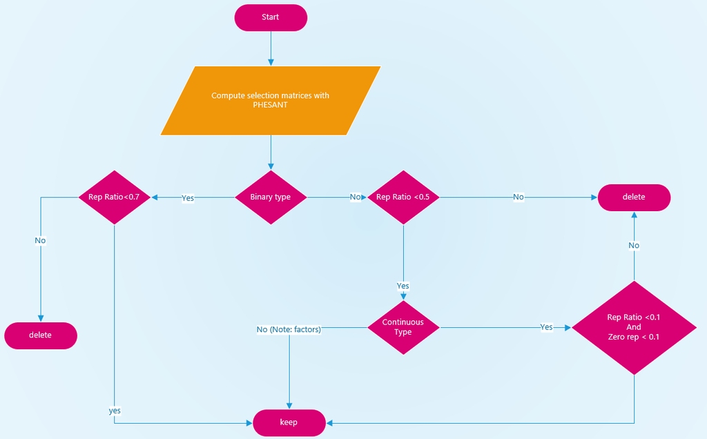

variable selection process

```r
library(knitr)
select_df <- select_matrice(diet_data)
kable(head(select_df))
```

|  | mean | max | min | std | distinct_n | freq_val | rept_n | na_n | zero_n | phesant | rept_ratio | zero_ratio |
| --- | --- | --- | --- | --- | --- | --- | --- | --- | --- | --- | --- | --- |
| WTDRD1 | 42773.119774 | 691139.5 | 0 | 47109.7141 | 34855 | 0 | 1482 | 1591 | 1482 | continuous | 0.0358 | 0.0358 |
| DR1DRSTZ | 1.277602 | 5.0 | 1 | 1.0071 | 3 | 1 | 38364 | 0 | 0 | ordered | 0.9258 | 0.0000 |
| DR1EXMER | 42.279105 | 91.0 | 2 | 22.8412 | 40 | 25 | 5315 | 2810 | 0 | continuous | 0.1283 | 0.0000 |
| DRABF | 2.000000 | 2.0 | 2 | 0.0000 | 2 | 2 | 38364 | 3073 | 0 | binary | 0.9258 | 0.0000 |
| DRDINT | 1.883276 | 2.0 | 1 | 0.3211 | 3 | 2 | 33886 | 3073 | 0 | ordered | 0.8178 | 0.0000 |
| DR1DAY | 4.456235 | 7.0 | 1 | 2.1706 | 8 | 6 | 9221 | 2810 | 0 | ordered | 0.2225 | 0.0000 |

```r
select_vars <- select_df |> filter((phesant != 'binary' & rept_ratio < 0.5) |
                                     (phesant == 'binary' & rept_ratio < 0.7)) |>
              filter(!(phesant=='continuous' & rept_ratio > 0.1 & zero_ratio > 0.1))

select_vars <- rownames(select_vars)

select_vars
```

```
##  [1] "WTDRD1"   "DR1EXMER" "DR1DAY"   "DRQSPREP" "DR1TNUMF" "DR1TKCAL"
##  [7] "DR1TPROT" "DR1TCARB" "DR1TSUGR" "DR1TFIBE" "DR1TTFAT" "DR1TSFAT"
## [13] "DR1TMFAT" "DR1TPFAT" "DR1TCHOL" "DR1TATOC" "DR1TRET"  "DR1TVARA"
## [19] "DR1TBCAR" "DR1TCRYP" "DR1TLZ"   "DR1TVB1"  "DR1TVB2"  "DR1TNIAC"
## [25] "DR1TVB6"  "DR1TFOLA" "DR1TFA"   "DR1TFF"   "DR1TFDFE" "DR1TVB12"
## [31] "DR1TVC"   "DR1TVK"   "DR1TCALC" "DR1TPHOS" "DR1TMAGN" "DR1TIRON"
## [37] "DR1TZINC" "DR1TCOPP" "DR1TSODI" "DR1TPOTA" "DR1TSELE" "DR1TMOIS"
## [43] "DR1TS040" "DR1TS060" "DR1TS080" "DR1TS100" "DR1TS120" "DR1TS140"
## [49] "DR1TS160" "DR1TS180" "DR1TM161" "DR1TM181" "DR1TM201" "DR1TP182"
## [55] "DR1TP183" "DR1TP204"
```

## Removed variables

```r
discard_varible <- setdiff(colnames(diet_data),select_vars)
#discard variables
kable(select_df[discard_varible,])
```

|  | mean | max | min | std | distinct_n | freq_val | rept_n | na_n | zero_n | phesant | rept_ratio | zero_ratio |
| --- | --- | --- | --- | --- | --- | --- | --- | --- | --- | --- | --- | --- |
| DR1DRSTZ | 1.2776021 | 5.000 | 1 | 1.0071 | 3 | 1 | 38364 | 0 | 0 | ordered | 0.9258 | 0.0000 |
| DRABF | 2.0000000 | 2.000 | 2 | 0.0000 | 2 | 2 | 38364 | 3073 | 0 | binary | 0.9258 | 0.0000 |
| DRDINT | 1.8832760 | 2.000 | 1 | 0.3211 | 3 | 2 | 33886 | 3073 | 0 | ordered | 0.8178 | 0.0000 |
| DR1LANG | 1.1870198 | 6.000 | 1 | 0.5615 | 7 | 1 | 33179 | 2778 | 0 | ordered | 0.8007 | 0.0000 |
| DBQ095Z | 3.4585685 | 99.000 | 1 | 11.8195 | 7 | 1 | 24275 | 2819 | 0 | ordered | 0.5858 | 0.0000 |
| DRQSDIET | 1.8839371 | 9.000 | 1 | 0.6415 | 4 | 2 | 32431 | 2820 | 0 | ordered | 0.7827 | 0.0000 |
| DR1TATOA | 0.5739830 | 99.870 | 0 | 2.9826 | 1157 | 0 | 34489 | 3073 | 34489 | continuous | 0.8323 | 0.8323 |
| DR1TACAR | 387.3703472 | 61530.000 | 0 | 1147.9810 | 3255 | 0 | 4203 | 3073 | 4203 | continuous | 0.1014 | 0.1014 |
| DR1TLYCO | 5056.9475550 | 185358.000 | 0 | 9212.5583 | 11967 | 0 | 9661 | 3073 | 9661 | continuous | 0.2331 | 0.2331 |
| DR1TB12A | 0.9029969 | 89.230 | 0 | 2.5491 | 1669 | 0 | 28708 | 3073 | 28708 | continuous | 0.6928 | 0.6928 |
| DR1TCAFF | 153.3729017 | 5151.000 | 0 | 208.6996 | 1146 | 0 | 5347 | 3073 | 5347 | continuous | 0.1290 | 0.1290 |
| DR1TTHEO | 35.0806746 | 2038.000 | 0 | 77.3888 | 579 | 0 | 19475 | 3073 | 19475 | continuous | 0.4700 | 0.4700 |
| DR1TALCO | 9.9373397 | 831.600 | 0 | 28.0568 | 1231 | 0 | 29235 | 3073 | 29235 | continuous | 0.7055 | 0.7055 |
| DR1TM221 | 0.0321512 | 9.992 | 0 | 0.1296 | 627 | 0 | 8772 | 3073 | 8772 | continuous | 0.2117 | 0.2117 |
| DR1TP184 | 0.0118475 | 0.889 | 0 | 0.0380 | 356 | 0 | 20873 | 3073 | 20873 | continuous | 0.5037 | 0.5037 |
| DR1TP205 | 0.0382599 | 3.713 | 0 | 0.1270 | 881 | 0 | 6279 | 3073 | 6279 | continuous | 0.1515 | 0.1515 |
| DR1TP225 | 0.0228755 | 2.203 | 0 | 0.0447 | 397 | 0 | 7529 | 3073 | 7529 | continuous | 0.1817 | 0.1817 |
| DR1TP226 | 0.0760148 | 8.717 | 0 | 0.2045 | 1187 | 0 | 6078 | 3073 | 6078 | continuous | 0.1467 | 0.1467 |
| DR1_300 | 2.1557719 | 9.000 | 1 | 0.7907 | 6 | 2 | 27962 | 2810 | 0 | ordered | 0.6748 | 0.0000 |

## final selected varibles

Although the above process selected variables with reasonable distribution, some of the variables rather overlap. We can view the official documents on [NHANES](https://wwwn.cdc.gov/Nchs/Nhanes/2017-2018/DR1TOT_J.htm) or [look up varibles tool](https://ccb-hms.github.io/Imputation/check_vars.html).

- DR1TS040 - SFA 4:0 (Butanoic) (gm)
- DR1TS060 - SFA 6:0 (Hexanoic) (gm)
- DR1TS080 - SFA 8:0 (Octanoic) (gm)
- DR1TS100 - SFA 10:0 (Decanoic) (gm)
- DR1TS120 - SFA 12:0 (Dodecanoic) (gm)
- DR1TS140 - SFA 14:0 (Tetradecanoic) (gm)
- DR1TS160 - SFA 16:0 (Hexadecanoic) (gm)
- DR1TS180 - SFA 18:0 (Octadecanoic) (gm)

one of:

- DR1TP182 - PFA 18:2 (Octadecadienoic) (gm)
- DR1TP183 - PFA 18:3 (Octadecatrienoic) (gm)
- DR1TP204 - PFA 20:4 (Eicosatetraenoic) (gm)

one of:

- DR1TM161 - MFA 16:1 (Hexadecenoic) (gm)
- DR1TM181 - MFA 18:1 (Octadecenoic) (gm)
- DR1TM201 - MFA 20:1 (Eicosenoic) (gm)

## Correlation Matrix

```r
library(corrplot)
diet_data <- data[, c('RIAGENDR', diet_cols)]
sfa_data <- na.omit(diet_data[, c(
  "DR1TS040",
  "DR1TS060",
  'DR1TS080',
  "DR1TS100",
  'DR1TS120',
  "DR1TS140",
  "DR1TS160",
  "DR1TS180"
)])
sfa_cor <- cor(sfa_data)

kable(sfa_cor)
```

|  | DR1TS040 | DR1TS060 | DR1TS080 | DR1TS100 | DR1TS120 | DR1TS140 | DR1TS160 | DR1TS180 |
| --- | --- | --- | --- | --- | --- | --- | --- | --- |
| DR1TS040 | 1.0000000 | 0.9451709 | 0.7014727 | 0.8910142 | 0.3398543 | 0.9045715 | 0.6846288 | 0.6533765 |
| DR1TS060 | 0.9451709 | 1.0000000 | 0.7666548 | 0.9292833 | 0.3950463 | 0.8998566 | 0.6729055 | 0.6303626 |
| DR1TS080 | 0.7014727 | 0.7666548 | 1.0000000 | 0.9025575 | 0.8459346 | 0.8390870 | 0.5520338 | 0.5309012 |
| DR1TS100 | 0.8910142 | 0.9292833 | 0.9025575 | 1.0000000 | 0.6450557 | 0.9473956 | 0.6862728 | 0.6478279 |
| DR1TS120 | 0.3398543 | 0.3950463 | 0.8459346 | 0.6450557 | 1.0000000 | 0.5771876 | 0.3286435 | 0.3354644 |
| DR1TS140 | 0.9045715 | 0.8998566 | 0.8390870 | 0.9473956 | 0.5771876 | 1.0000000 | 0.8012570 | 0.7766523 |
| DR1TS160 | 0.6846288 | 0.6729055 | 0.5520338 | 0.6862728 | 0.3286435 | 0.8012570 | 1.0000000 | 0.9523975 |
| DR1TS180 | 0.6533765 | 0.6303626 | 0.5309012 | 0.6478279 | 0.3354644 | 0.7766523 | 0.9523975 | 1.0000000 |

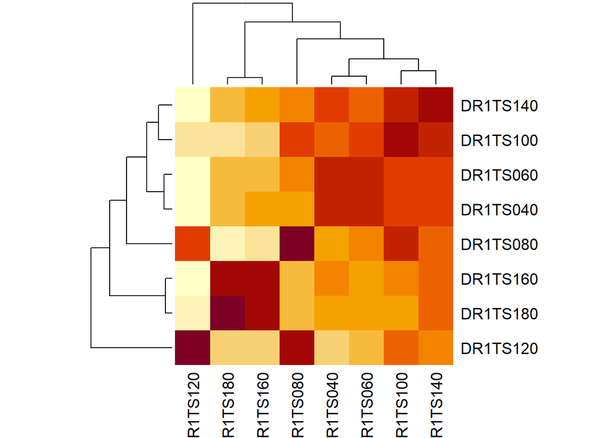

```r
heatmap(sfa_cor)
```

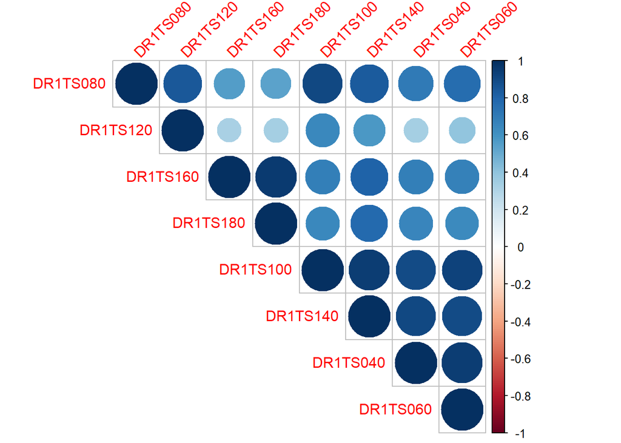

```r
corrplot(sfa_cor,
         type = "upper",
         order = "hclust",
         tl.srt = 45)
```

```r
pfa_data <- na.omit(diet_data[, c('DR1TP182', 'DR1TP183', 'DR1TP204')])
cor(pfa_data)
```

```
##           DR1TP182  DR1TP183  DR1TP204
## DR1TP182 1.0000000 0.8286496 0.4189894
## DR1TP183 0.8286496 1.0000000 0.3349582
## DR1TP204 0.4189894 0.3349582 1.0000000
```

```r
mfa_data <- na.omit(diet_data[, c('DR1TM161', 'DR1TM181', 'DR1TM201')])
cor(mfa_data)
```

```
##           DR1TM161  DR1TM181  DR1TM201
## DR1TM161 1.0000000 0.7397781 0.4763133
## DR1TM181 0.7397781 1.0000000 0.6319570
## DR1TM201 0.4763133 0.6319570 1.0000000
```

## PCA Analysis

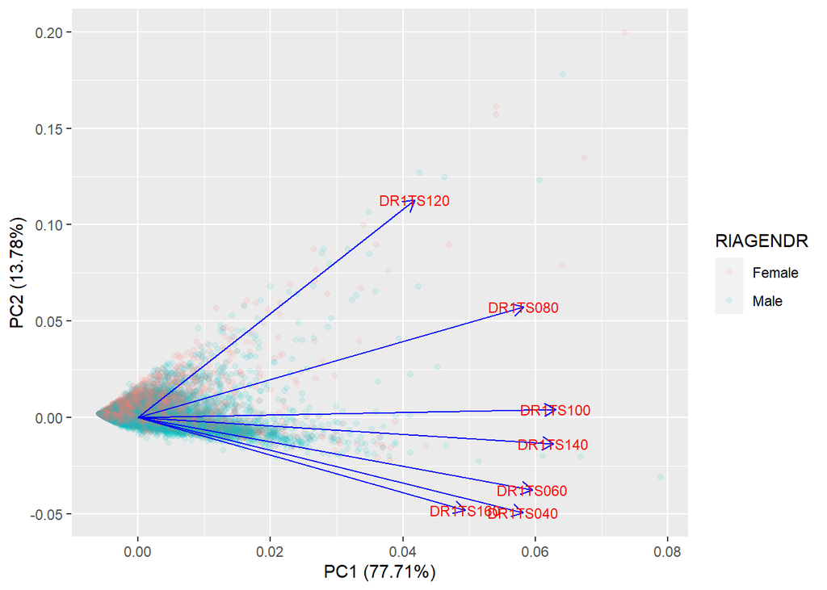

```r
library(ggfortify)


sfa_data <-
  na.omit(diet_data[, c(
    "RIAGENDR",
    "DR1TS040",
    "DR1TS060",
    'DR1TS080',
    "DR1TS100",
    'DR1TS120',
    "DR1TS140",
    "DR1TS160",
    "DR1TS180"
  )])

sfa_pca <- prcomp(sfa_data[, 2:8],
                  center = TRUE, scale. = TRUE)

autoplot(
  sfa_pca,
  data = sfa_data,
  colour = 'RIAGENDR',
  loadings = TRUE,
  loadings.colour = 'blue',
  loadings.label = TRUE,
  loadings.label.size = 3,
  alpha = 0.1
)
```

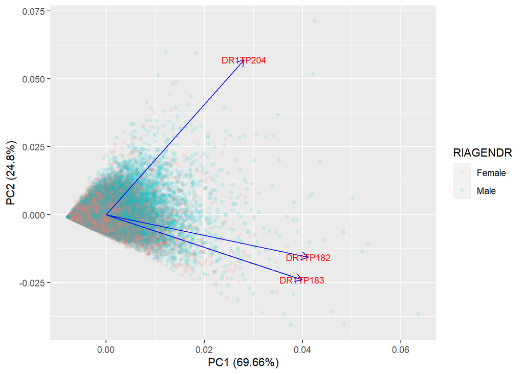

```r
pfa_data <-
  na.omit(diet_data[, c("RIAGENDR", 'DR1TP182', 'DR1TP183', 'DR1TP204')])

pfa_pca <- prcomp(pfa_data[, 2:4],
                  center = TRUE, scale. = TRUE)

autoplot(
  pfa_pca,
  data = sfa_data,
  colour = 'RIAGENDR',
  loadings = TRUE,
  loadings.colour = 'blue',
  loadings.label = TRUE,
  loadings.label.size = 3,
  alpha = 0.1
)
```

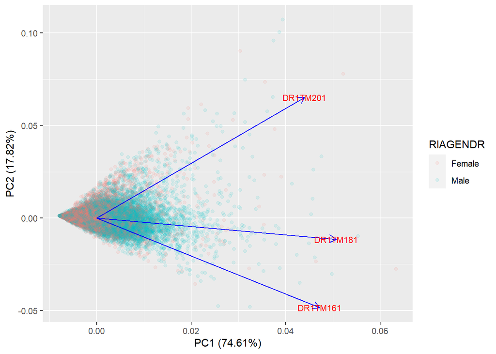

```r
mfa_data <-
  na.omit(diet_data[, c("RIAGENDR", 'DR1TM161', 'DR1TM181', 'DR1TM201')])

mfa_pca <- prcomp(mfa_data[, 2:4],
                  center = TRUE, scale. = TRUE)

autoplot(
  mfa_pca,
  data = sfa_data,
  colour = 'RIAGENDR',
  loadings = TRUE,
  loadings.colour = 'blue',
  loadings.label = TRUE,
  loadings.label.size = 3,
  alpha = 0.1
)
```

```r
select_vars <- select_vars[!(select_vars %in% c('DR1TM181','DR1TM201','DR1TP182',
                                                'DR1TS040','DR1TS060','DR1TS080',
                                                'DR1TS100','DR1TS120','DR1TS140',
                                                'DR1TS160','DR1TS180','DR1TP204',
                                                'DR1TP182'))]

select_vars
```

```
##  [1] "WTDRD1"   "DR1EXMER" "DR1DAY"   "DRQSPREP" "DR1TNUMF" "DR1TKCAL"
##  [7] "DR1TPROT" "DR1TCARB" "DR1TSUGR" "DR1TFIBE" "DR1TTFAT" "DR1TSFAT"
## [13] "DR1TMFAT" "DR1TPFAT" "DR1TCHOL" "DR1TATOC" "DR1TRET"  "DR1TVARA"
## [19] "DR1TBCAR" "DR1TCRYP" "DR1TLZ"   "DR1TVB1"  "DR1TVB2"  "DR1TNIAC"
## [25] "DR1TVB6"  "DR1TFOLA" "DR1TFA"   "DR1TFF"   "DR1TFDFE" "DR1TVB12"
## [31] "DR1TVC"   "DR1TVK"   "DR1TCALC" "DR1TPHOS" "DR1TMAGN" "DR1TIRON"
## [37] "DR1TZINC" "DR1TCOPP" "DR1TSODI" "DR1TPOTA" "DR1TSELE" "DR1TMOIS"
## [43] "DR1TM161" "DR1TP183"
```

```r
write(select_vars, "data/select_vars.txt")

# we can read them varibles later by
# selected_cols <- read.delim("data/select_vars.txt",header = FALSE)$V1
```